# Dynamics Homework

Dynamics & Simulation

Author

Suraj Dayma

Published

October 3, 2026

# P01. ODE — A Particle Problem

## Problem

Set up (define system, draw FBD, write ODEs) a particle problem. Just one particle. 2D or 3D, your choice. Use a force, or forces that you like (gravity, spring, air friction). Any example of interest. Find a numerical solution. Graph it. Animate it. Try to make an interesting observation.

## ODE

Random ODE solved via custom Euler solver.

```matlab
F1 = sin(t) * i_hat + cos(t) * j_hat;
F2 = cos(t) * i_hat + sin(t) * j_hat;

xdot = v;
vdot = F1 + F2;
```

## Trajectory

For the initial conditions of `x,y,vx,vy = z0 = [0, 0, 0.5, -0.5];`

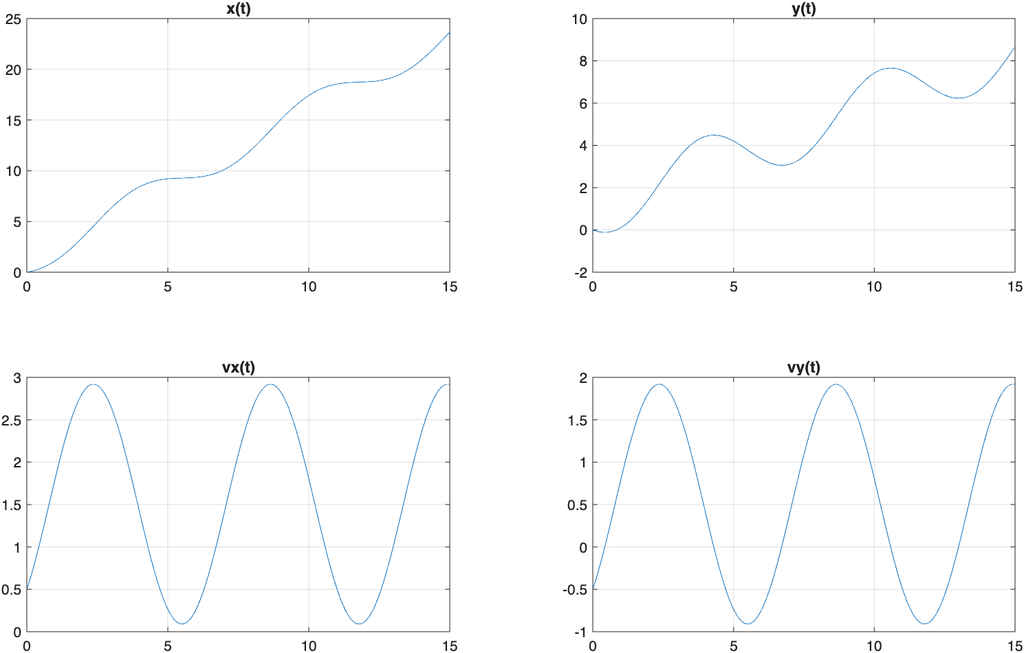

Variables over time

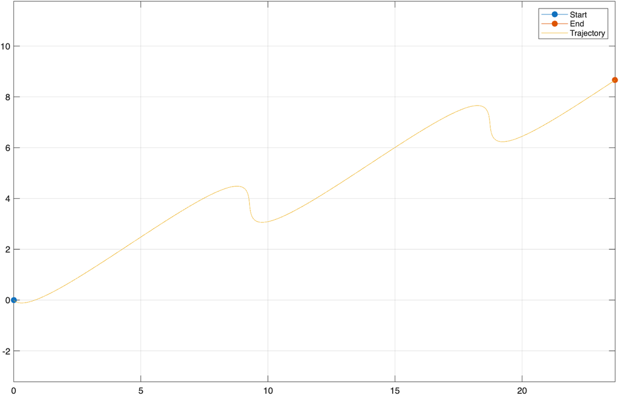

Phase Plot

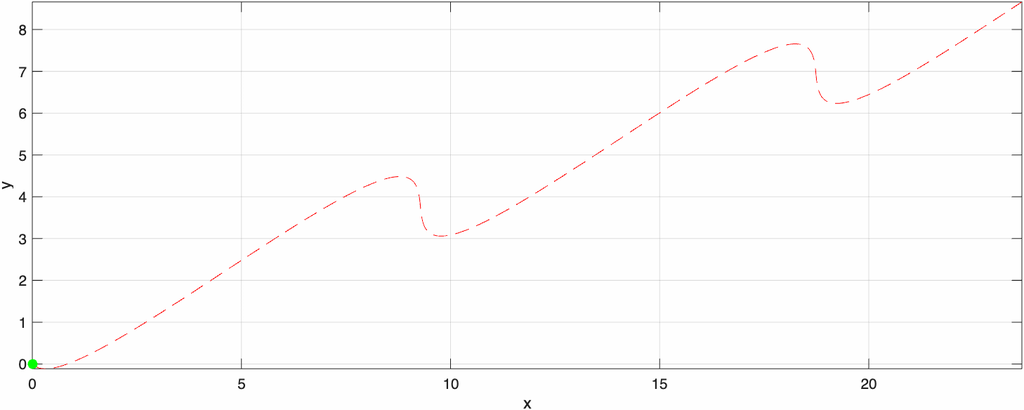

Animation of Trajectory

# P02. Vectors in 3D

*Given four random points $\bup{r}_A, \bup{r}_B, \bup{r}_C, \bup{r}_D$ and a force $\bup{F}$, write single vector formulas for:

1. the minimum distance between lines $AB$ and $CD$
2. the end points of that shortest segment
3. the volume of tetrahedron $ABCD$ (derive “⅓ base × height”)
4. the tension in bar $AD$ when $A, B, C$ are fixed and connected by rods to $D$, where $\bup{F}$ is applied.*

# P03. More ODE & Animation Practice

*Pick a simple ODE system (harmonic oscillator, pendulum, Lorenz …) and solve it three ways:

1. a single script with a plain Euler loop
2. your own Euler solver function calling a RHS function
3. ODE45.
4. study accuracy vs. step size with Euler
5. vary `RelTol`/`AbsTol` in ODE45 to judge whether MATLAB estimates its own accuracy well.*

# P06. Spring and Mass (2D)

A mass $m$ on a spring $(k, L_0)$ pinned at the origin, under gravity, starting from $\bup{r}_0, \bup{v}_0$.  
(a) Find the EoM  
(b) plot and animate the trajectory  
(c) list and carry out as many sanity checks as possible (e.g. $k = 0$ → balistics; $x_0 = v_{x0} = 0$ → stays on the $y$-axis; $g = 0, \bup{v}_0 = 0$ → radial harmonic oscillation; $L_0 = 0$ → …).

# P07. Simple Animation of a Shape

*Draw an object (face, house, …) and make it move smoothly and interestingly on screen using only rigid motions — translations and rotations, no distortion.*

I defined a rectangle with 4 points and applied these transformations:  
1. translate by $\vec{T} = (2 2)^T$ 2. rotate by $45^\circ$ using rotation matrix.

Once we have initial and final coordinates of the shape, I linearly interpolate them from time 0 to some time tf within which the animation occurs.

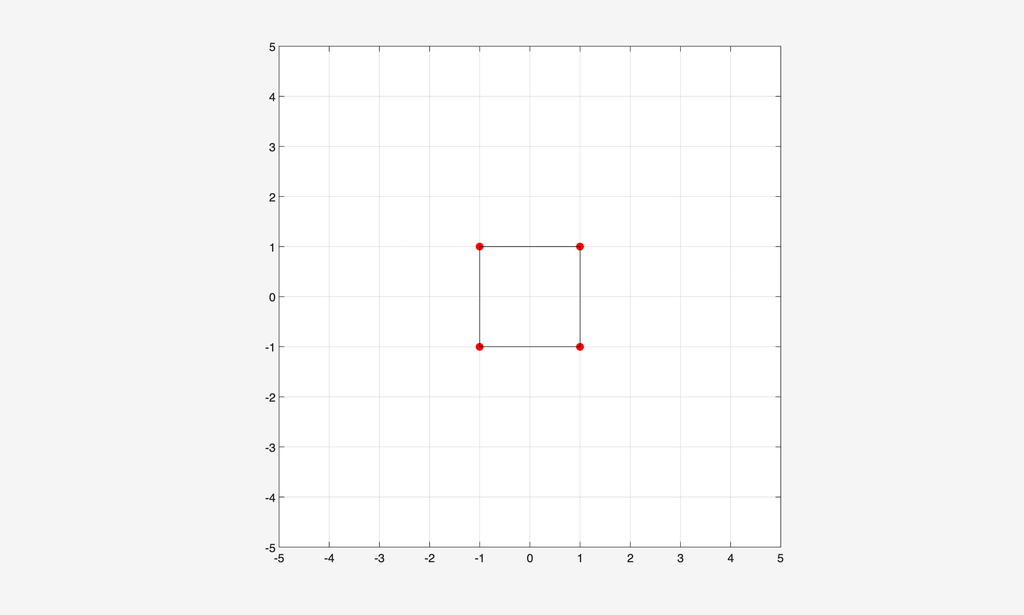

Animation of Rectangle

# P08. Simplest Dynamics in Polar Coordinates

*A force-free particle on a plane, posed in polar coordinates: (a) write $\bup{a} = \bup{0}$ as ODEs in $(r, \theta)$; (b) solve numerically for various ICs; (c) check the path is a straight line at constant speed; (d) define a quantitative “straightness” measure and evaluate it; (e) does it improve as tolerances are tightened?*

# P09. Cannon Ball (Linear Drag)

*A cannon ball launched at angle $\theta$ and speed $v_0$ with gravity and linear viscous drag $|cv|$. (a) Analytical $x(t), y(t)$; (b) numerical solution for $\theta = \pi/4$, $v_0 = g = m = c = 1$; (c) compare — error at $t = 2$ vs. tolerances; (d) trajectories as $v_0 \to \infty$ — what shape?; (e) where does the range-maximising angle $\theta^*$ tend as $v_0 \to \infty$?*

# P11. Central Force

*Only force is central, $\bup{F} = -F(r)\,\hat{\bup{e}}_r$. (a) Find $F(r)$ such that, across circular orbits, the speed is independent of radius. (b) Numerically (with `fsolve` over ICs and period) find a periodic orbit that is neither circular nor straight, for a force law other than a linear spring or inverse-square gravity; comment on chaotic-looking failed searches and on the minimum number of loops for power laws.*

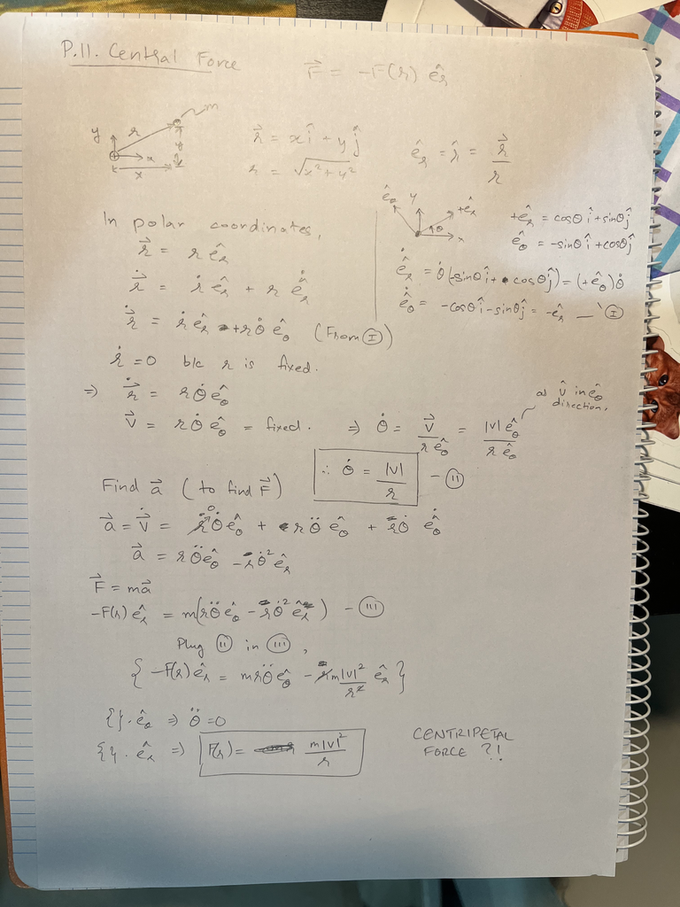

## Periodic Solutions

### For $F(r) = 1$

Found using fsolve root finding with initial conditions - [ 4.837094489229557 0.113739688509354 0.481812323218859 1.333913034846417 ] time period = 49.578757824567518

Using jacobian analysis, we find this is an unstable periodic motion. eigvals of jacobian = [ 0.786327175145648 0.786327175145648 1.187326408237210 0.842228377131789]

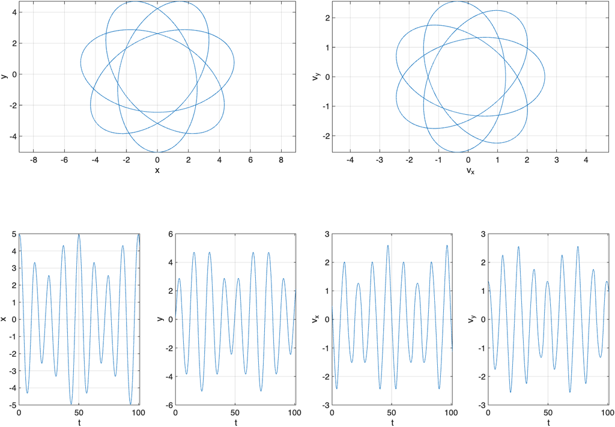

Trajectories

# P13. Statics vs Dynamics — Two Spring Damper System

*A 2D point mass under gravity, connected to anchors $A$ and $B$ by springs $(k_A, L_A), (k_B, L_B)$ with parallel dashpots $(c_A, c_B)$ and air drag $c_d$. (a) Find an equilibrium; (b) simulate the motion; (c) find **all** equilibria and the most/least number possible as parameters vary; (d) determine stability both by simulation near the equilibrium and by eigenvalues of the linearised system.*

## Intro

System animation, fixed point analysis and clustering, and linear stability analysis for the **Two Spring and Two Damper System** with drag.

## Problem and Dynamics:

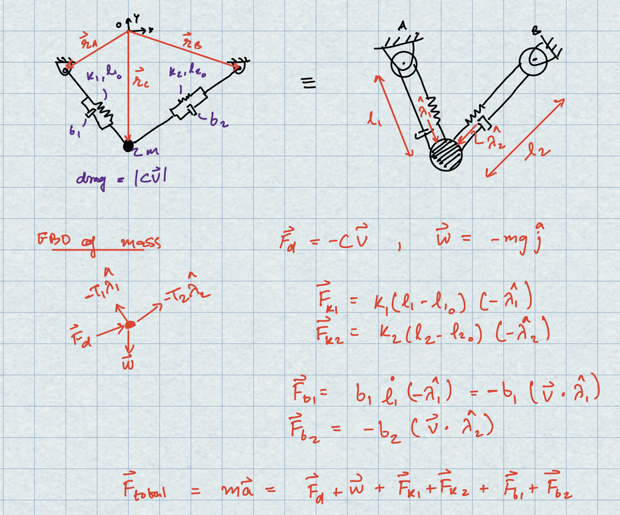

Force Balance

## Fixed Points

The fixed points were found using `fsolve`, and clustering of fixed points was performed by using the following algorithms:

1. KMeans: within cluster sum of squares was found was varying K and the best K was determined by the elbow method.
2. DBScan: the distance parameter was kept very small (0.005) which converged correctly for every scenario I tried (except the infinite fixed point cases).

### Fixed Points = 2

```matlab
% System Constants
p.m = 1;
p.g = 10;

p.b1 = 1;
p.b2 = 1;

p.d = 0.6; % drag coef

p.k1 = 1;
p.k2 = 10;
p.l1_0 = 1;
p.l2_0 = 1;

p.r1 = [-1; 0];
p.r2 = [1; 0];
```

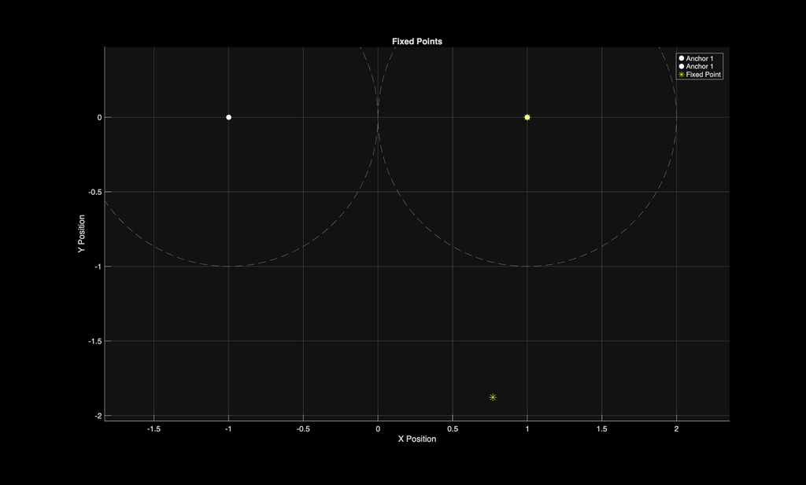

Fixed Points

Both KMeans and DBScan provided the right answer for this.

### Fixed Points = 5

```matlab
% System Constants
p.m = 1;
p.g = 0;

p.b1 = 1;
p.b2 = 1;

p.d = 1; % drag coef

p.k1 = 10;
p.k2 = 10;
p.l1_0 = 1.5;
p.l2_0 = 1.5;

p.r1 = [-1; 0];
p.r2 = [1; 0];
```

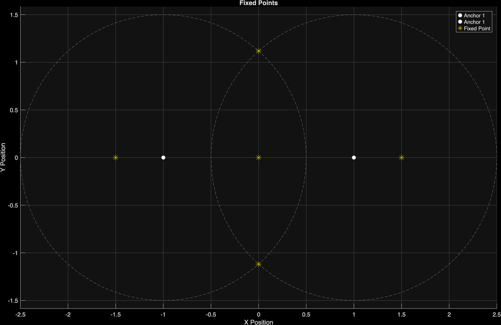

Fixed Points

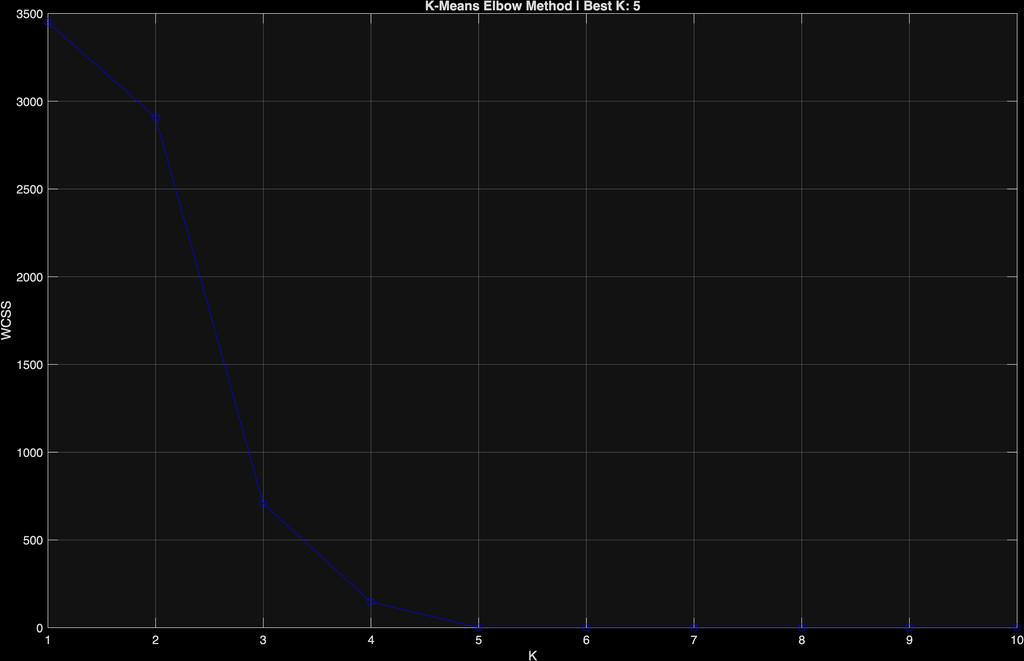

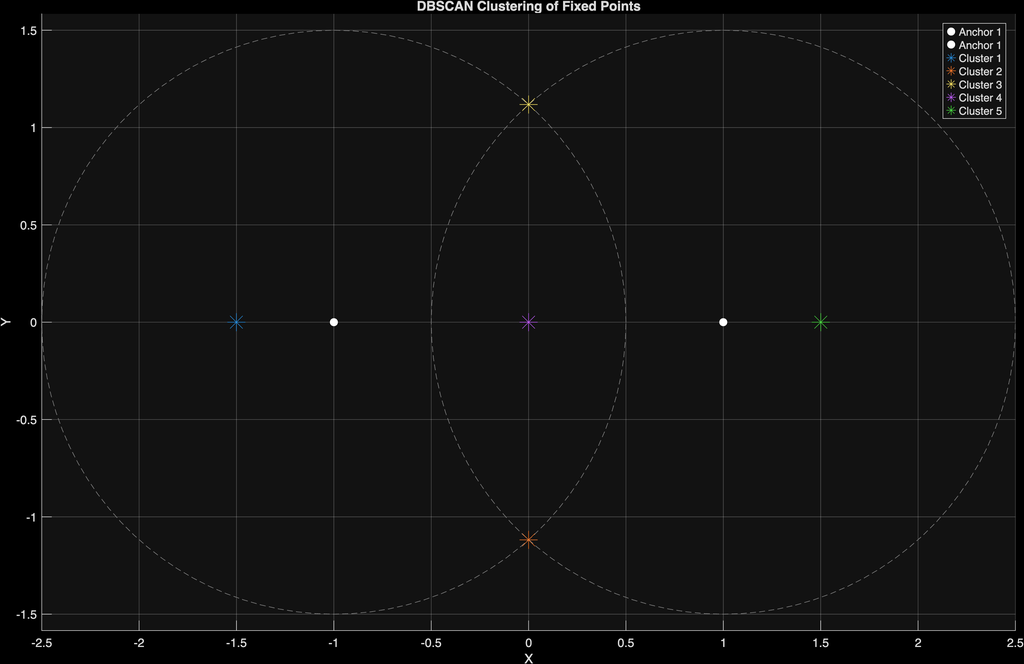

DBScan - Correct Identification

### Fixed Points = 1

```matlab
% System Constants
p.m = 1;
p.g = 10;

p.b1 = 1;
p.b2 = 1;;

p.d = 1; % drag coef

p.k1 = 10;
p.k2 = 10;
p.l1_0 = 1;
p.l2_0 = 1;

p.r1 = [-1; 0];
p.r2 = [1; 0];
```

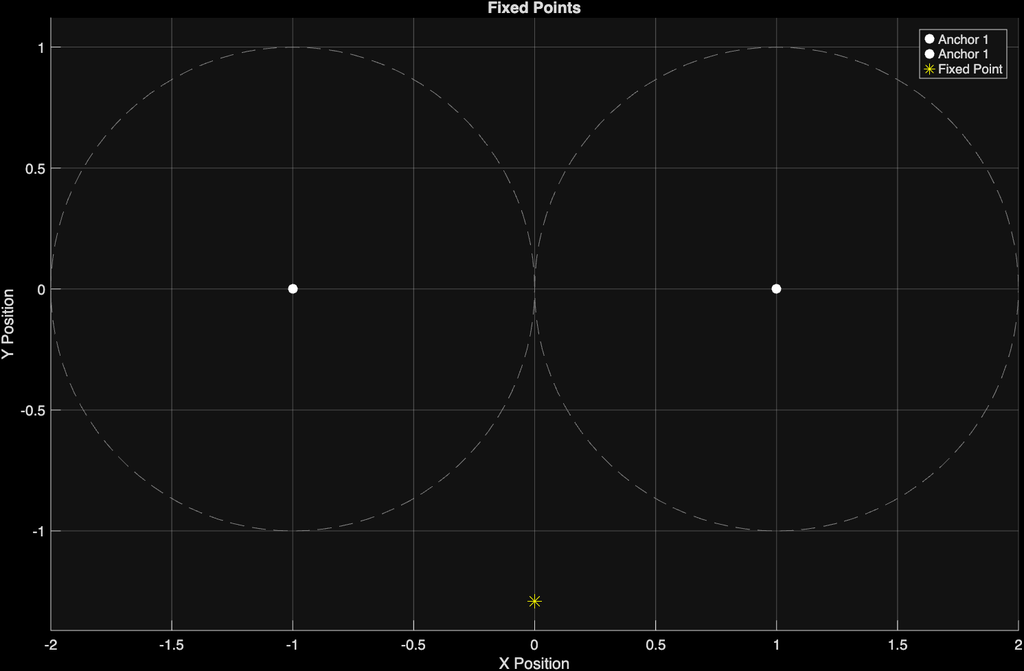

Fixed Points

Both KMeans and DBScan provided the right answer for this.

### Fixed Points = 4, Two of them are very close

```matlab
% System Constants
p.m = 1;
p.g = 0;

p.b1 = 1;
p.b2 = 1;;

p.d = 1; % drag coef

p.k1 = 10;
p.k2 = 10;
p.l1_0 = 1;
p.l2_0 = 1;

p.r1 = [-1; 0];
p.r2 = [1; 0];
```

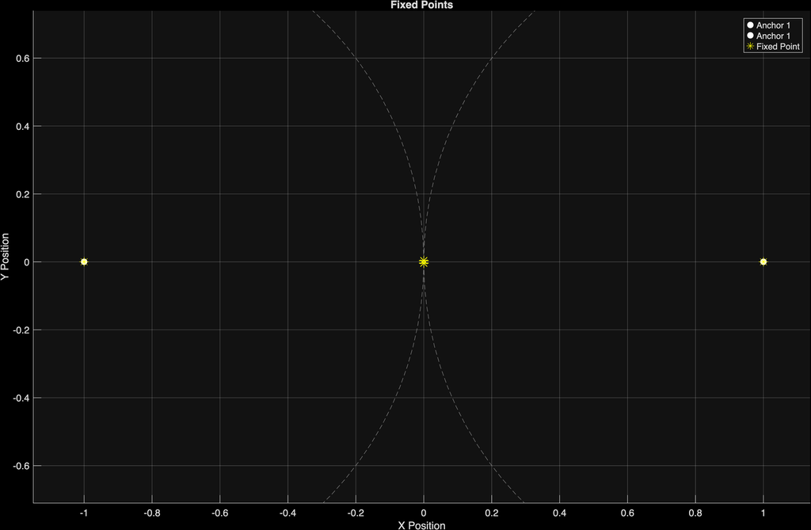

Fixed Points

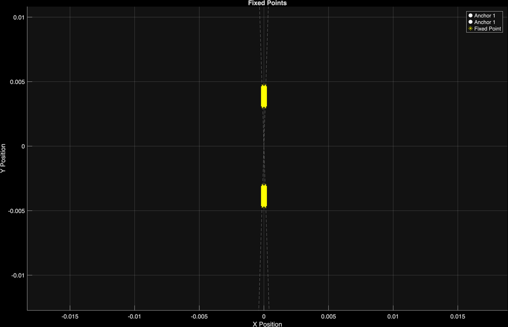

2 Fixed Points Closeby

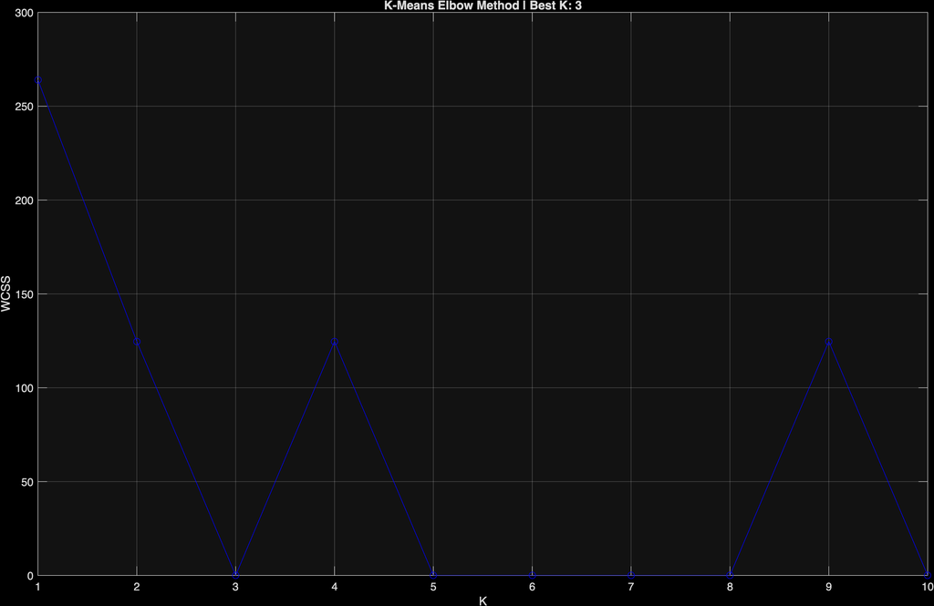

KMean - Best K = 3: WRONG

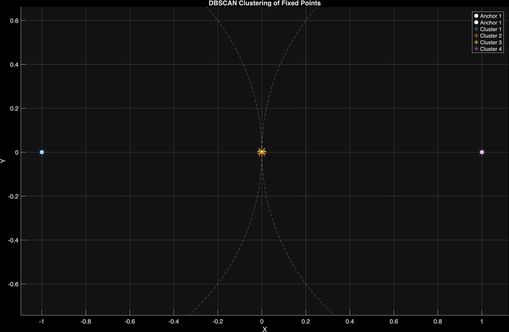

DBScan - Correct Identification

### Fixed Points = 3

```matlab
% System Constants
p.m = 1;
p.g = 1;

p.b1 = 1;
p.b2 = 1;

p.d = 1; % drag coef

p.k1 = 1;
p.k2 = 1;
p.l1_0 = 1;
p.l2_0 = 2;

p.r1 = [-1; 0];
p.r2 = [1; 0];
```

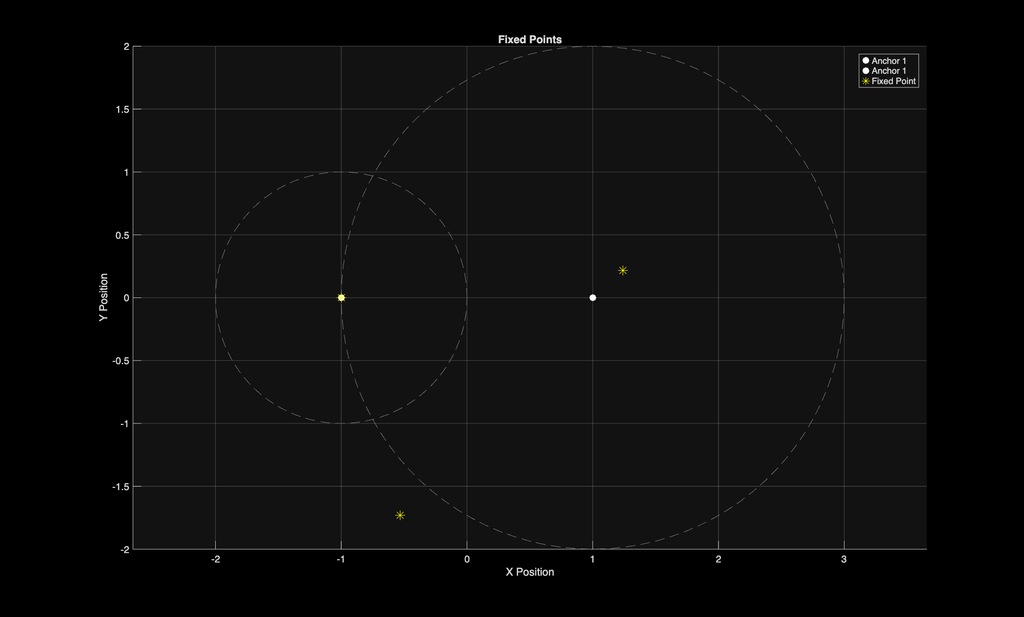

Fixed Points

DBScan was correct all the times, KMeans sometimes said best K was 2, while other times said it was 3.

### Fixed Points = Infinite

When gravity is off, and either of the spring constants are zero, all points on the free length circle of the active spring are valid unique fixed points.

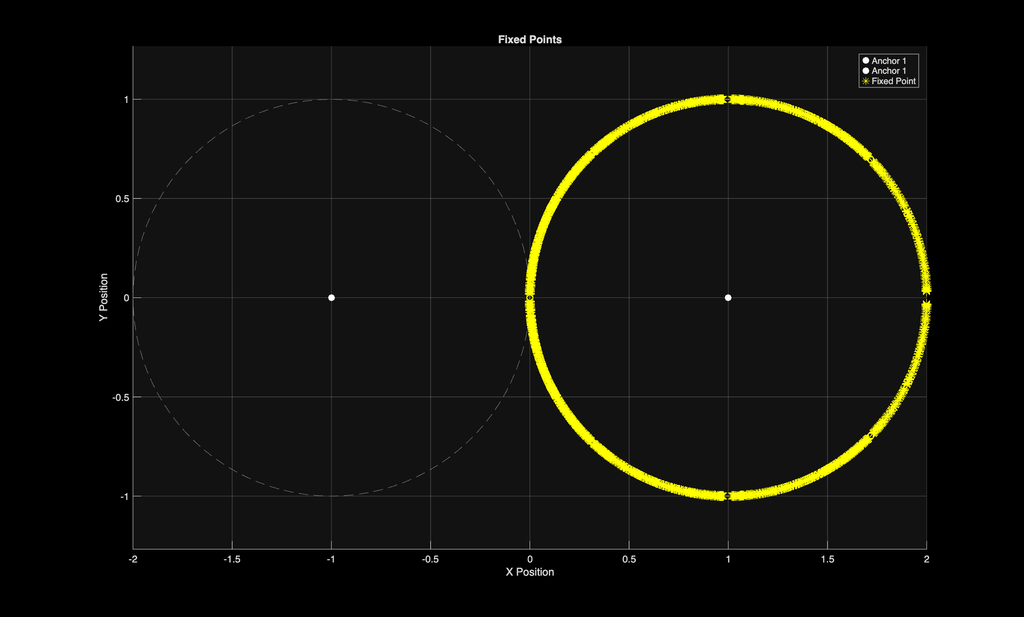

g = 0, k1 = 0 => inf FP

Also when gravity is off, and both the springs are active, but the anchor positions are the same, we get infinite fixed points.

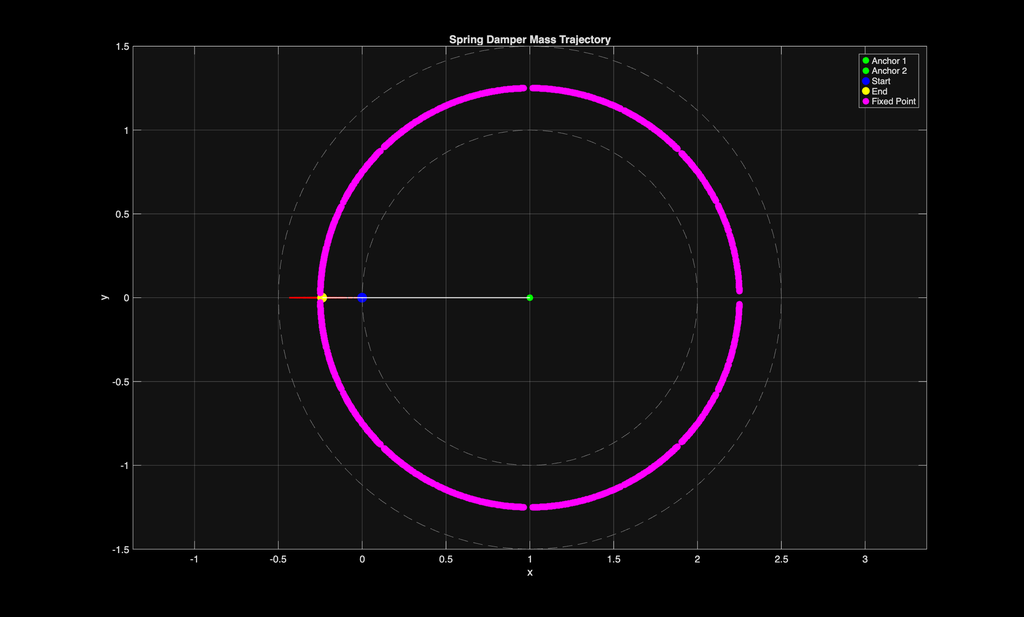

g = 0, rA=rB => inf FP

## Linearised Motion

**Task:**

- Using the Jacobian supplied by fsolve at one of the stable fixed points, solve the linearized equations for motion for an initial condition near the fixed point.
- Using the same initial condition, use ODE45 to find the motion.
- Repeat for an unstable fixed point

**System Used:** The same parameters that resulted in 3 fixed points were used.

Stable Fixed Points:

- [-1; 0]
- [-0.5323; -1.7316]

Unstable Fixed Points:

- [1.2412; 0.2169]

### Response near stable fixed point

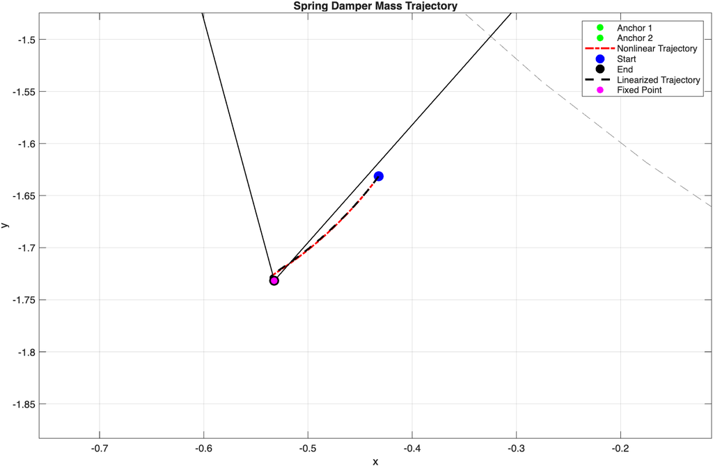

### Response near unstable fixed point

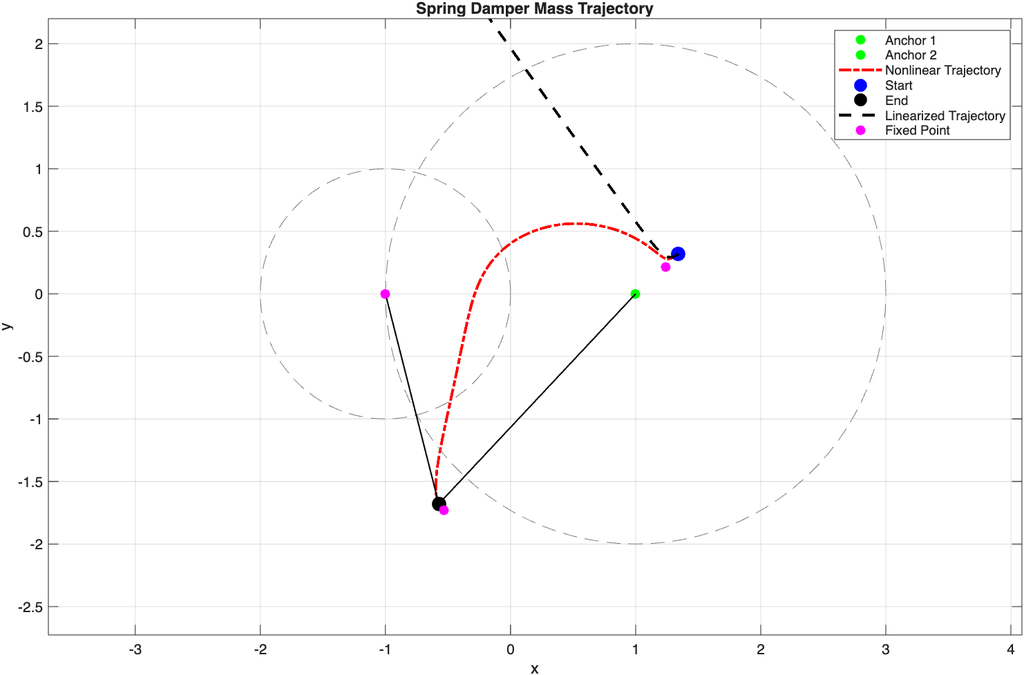

### Response When L0 = 0, b = 0

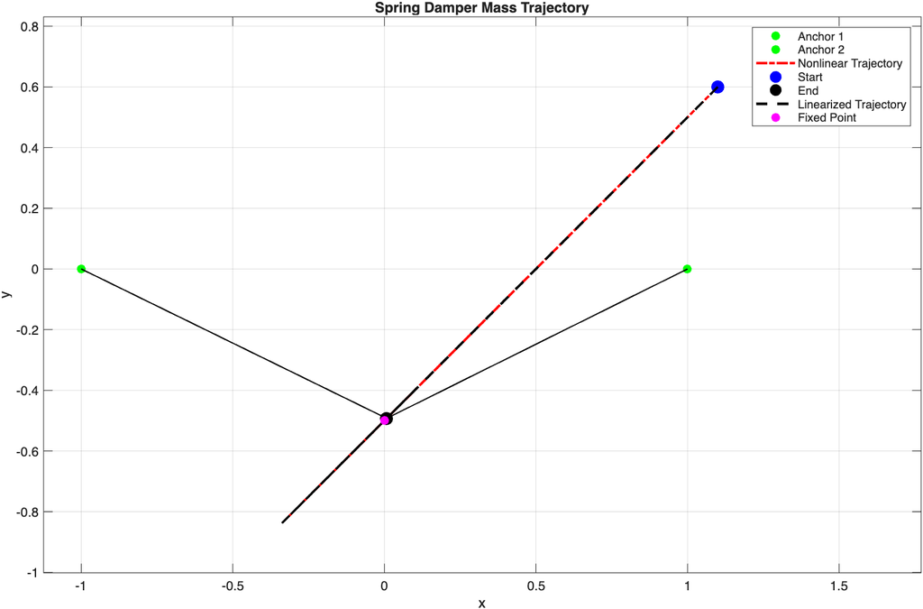

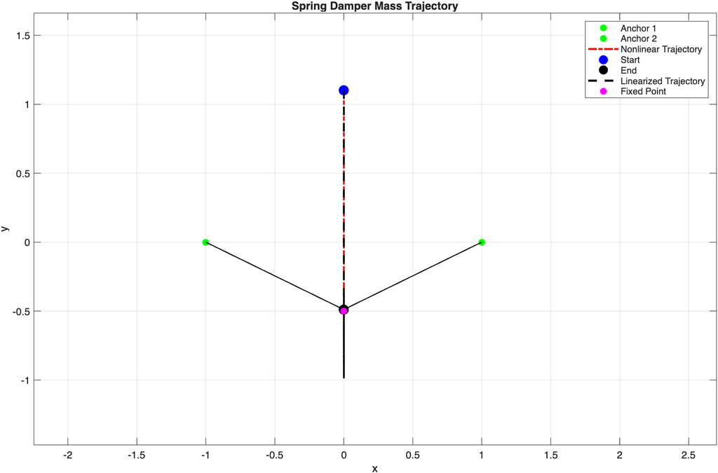

# P14. What Means “Rate of Change of Angular Momentum”?

*For a moving particle $P$ and a moving reference point $C$, decide for which definition of $\bup{H}_{/C}$ the equation $\bup{M}_C = \dot{\bup{H}}_{/C}$ holds (i.e. is consistent with $\bup{F} = m\bup{a}$): (a) $\bup{r}_{P/C'} \times \bup{v}_{P/0}\, m$ with $C'$ fixed and instantaneously coincident with $C$; (b) $\bup{r}_{P/C} \times \bup{v}_{P/0}\, m$; (c) $\bup{r}_{P/C} \times \bup{v}_{P/C}\, m$ — in general, or only in special cases?*

[figure not shown]

# P15. Potential Energy

*Find the potential-energy function for a set of 3D force fields: constant force, zero-rest-length spring, spring with rest length, inverse-square central force, general central force $f(r)$, spring and inverse-square attraction between two points, constant force along $\hat{\boldsymbol{\lambda}}$, and an $x$-only force $f(x)$ — verifying the given answers with multivariable calculus.*

[figure not shown]